# Vacation Package Project

### Number of Trips

```
ProdTaken         0    1   All
NumberOfTrips
All            3968  918  4886
2.0            1165  299  1464
3.0             992  231  1223
1.0             508  112   620
6.0             258   64   322
5.0             396   62   458
4.0             417   61   478
7.0             156   61   217
8.0              76   28   104
-------------------------------------------------------------------------------------------------------------------
ProdTaken             0         1
NumberOfTrips
7.0            0.718894  0.281106
8.0            0.730769  0.269231
2.0            0.795765  0.204235
6.0            0.801242  0.198758
3.0            0.811120  0.188880
1.0            0.819355  0.180645
5.0            0.864629  0.135371
4.0            0.872385  0.127615
```

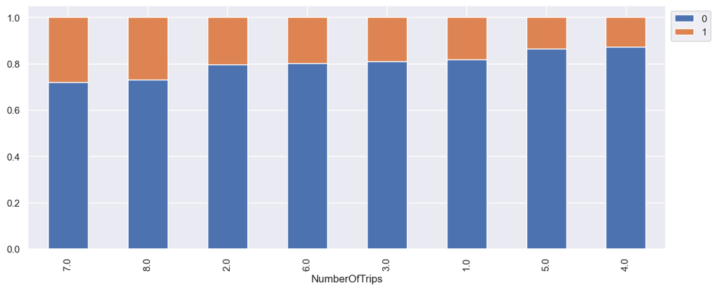

```python
stackedbarplot(df, 'NumberOfTrips', 'ProdTaken')
```

We have eight different categories for trips, and some of them share similar probabilities for package purchase rates. If we leave them be, we may overfit a model, so binning them (before later reconverting them to numeric fields) should help us prevent this. Due to how they are arranged with purchase rates we would like to group them like the following

- 1-3
- 4-5
- 6
- 7+

This will halve the number of catefories in our dataset and keep the general preditictive strengths of each one. 6 as a value is difficult due to not fitting well with 4 and five or seven and eight, and better fitting with 1-3. We just left it on its own to not make the eventual data difficult to understand

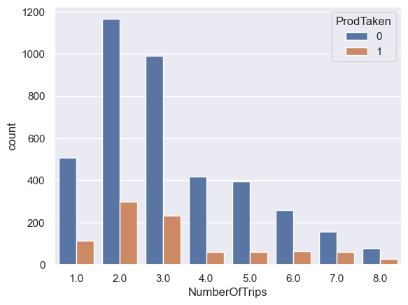

```python
sns.countplot(data= df, x='NumberOfTrips', hue = 'ProdTaken')
```

```python
conditions = [
    (df['NumberOfTrips'] >= 7),
    (df['NumberOfTrips'] == 6),
    (df['NumberOfTrips'] >= 4) & (df['NumberOfTrips'] <= 5),
    (df['NumberOfTrips'] >= 1) & (df['NumberOfTrips'] <= 3)
]

values = [
    '7+',
    '6',
    '4-5',
    '1-3'
]

df['NumberOfTrips'] = np.select(conditions, values)
```

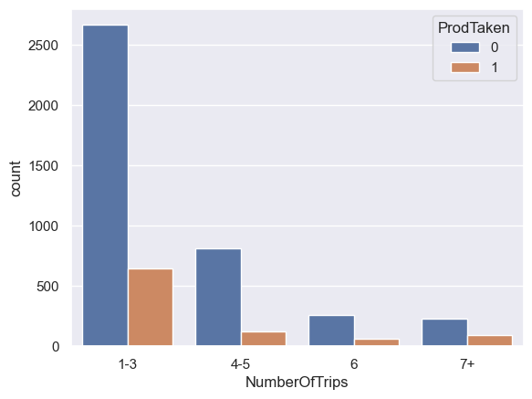

```python
sns.countplot(data=df, x='NumberOfTrips', order=['1-3', '4-5', '6', '7+'], hue='ProdTaken')
```

```
ProdTaken         0    1   All
NumberOfTrips
All            3968  918  4886
1-3            2665  642  3307
4-5             813  123   936
7+              232   89   321
6               258   64   322
-------------------------------------------------------------------------------------------------------------------
ProdTaken             0         1
NumberOfTrips
7+             0.722741  0.277259
6              0.801242  0.198758
1-3            0.805866  0.194134
4-5            0.868590  0.131410
```

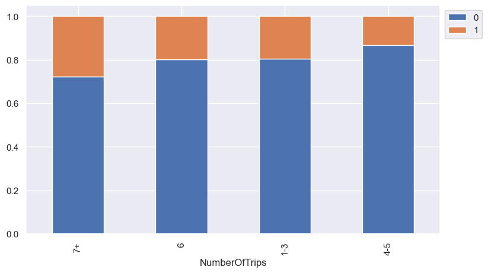

```python
stackedbarplot(df, 'NumberOfTrips', 'ProdTaken')
```

We can see that there was no significant chantges to the % of buyers in our data by grouping the numbers this way, so our model should be able to predict well without being overfit

### Designation

```
ProdTaken          0    1   All
Designation
All             3968  918  4886
Executive       1290  550  1840
Manager         1528  204  1732
Senior Manager   618  124   742
AVP              322   20   342
VP               210   20   230
-------------------------------------------------------------------------------------------------------------------
ProdTaken              0         1
Designation
Executive       0.701087  0.298913
Senior Manager  0.832884  0.167116
Manager         0.882217  0.117783
VP              0.913043  0.086957
AVP             0.941520  0.058480
```

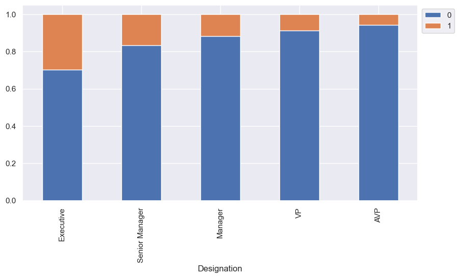

```python
stackedbarplot(df, 'Designation', 'ProdTaken')
```

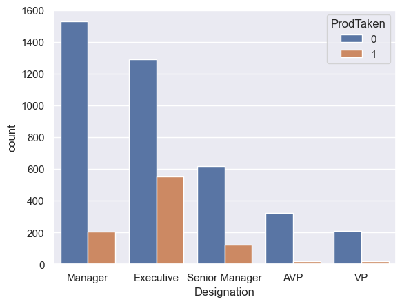

```python
sns.countplot(data=df, x='Designation', hue='ProdTaken')
```

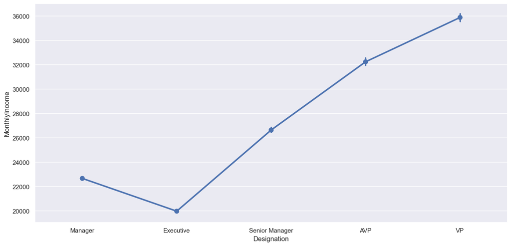

```python
plt.figure(figsize=(15, 7))
sns.pointplot(data=df, x='Designation', y='MonthlyIncome')
```

This data was a little bit weird both in its initial labelling and how we hope to consolidate it. Executives made the least, followed by managers, then senior managers, AVPs, and finally VPs made the most. We want to group VP and AVP, and then group Manager and Senior manager while leaving executive alone.

```python
conditions = [
    (df['Designation'] == 'Manager'),
    (df['Designation'] == 'Executive'),
    (df['Designation'] == 'Senior Manager'),
    (df['Designation'] == 'AVP'),
    (df['Designation'] == 'VP')
]

values = [
    'Management',
    'Executive',
    'Management',
    'VP and AVP',
    'VP and AVP'
]

df['Designation'] = np.select(conditions, values)
```

```
ProdTaken       0    1   All
Designation
All          3968  918  4886
Executive    1290  550  1840
Management   2146  328  2474
VP and AVP    532   40   572
-------------------------------------------------------------------------------------------------------------------
ProdTaken           0         1
Designation
Executive    0.701087  0.298913
Management   0.867421  0.132579
VP and AVP   0.930070  0.069930
```

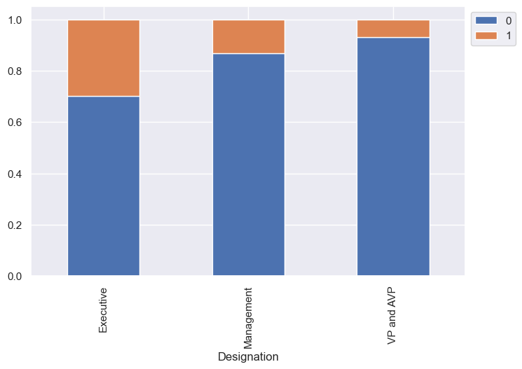

```python
stackedbarplot(df, 'Designation', 'ProdTaken')
```

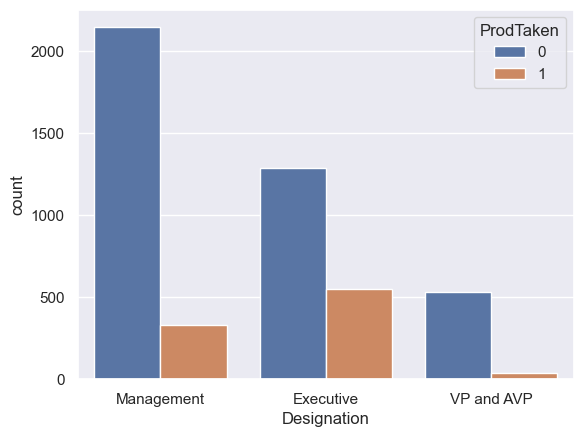

```python
sns.countplot(data=df, x='Designation', hue='ProdTaken')
```

The rough idea of the percentage of buyers has stayed intact after we have reduced the number of columns in Designation, and grouped them together. This also more accurately reflects the number of individuals set to be an executive

## Scale Numeric Columns

```python
df.head(5)
```

|  | ProdTaken | Age | TypeofContact | CityTier | DurationOfPitch | Occupation | Gender | NumberOfFollowups | ProductPitched | PreferredPropertyStar | MaritalStatus | NumberOfTrips | Passport | Designation | MonthlyIncome |
| --- | --- | --- | --- | --- | --- | --- | --- | --- | --- | --- | --- | --- | --- | --- | --- |
| 0 | 1 | 41.0 | Self Enquiry | 3 | 6.0 | Salaried | Female | 3.0 | Deluxe | 3.0 | Single | 1-3 | 1 | Management | 20993.0 |
| 1 | 0 | 49.0 | Company Invited | 1 | 14.0 | Salaried | Male | 4.0 | Deluxe | 4.0 | Divorced | 1-3 | 0 | Management | 20130.0 |
| 3 | 0 | 33.0 | Company Invited | 1 | 9.0 | Salaried | Female | 3.0 | Basic | 3.0 | Divorced | 1-3 | 1 | Executive | 17909.0 |
| 4 | 0 | 37.0 | Self Enquiry | 1 | 8.0 | Small Business | Male | 3.0 | Basic | 4.0 | Divorced | 1-3 | 0 | Executive | 18468.0 |
| 5 | 0 | 32.0 | Company Invited | 1 | 8.0 | Salaried | Male | 3.0 | Basic | 3.0 | Single | 1-3 | 0 | Executive | 18068.0 |

We have three numeric columns that have a wider range than the rest of our dataset that will need to be scaled accordingly. These are Age, Duration of Pitch and Monthly Income. Age has relatively few outliers, so it will just be min-maxed scaled to preserve the rough shape of the data. Monthly Income and Duration of Pitch have a long right tail, and will be log scaled to change the datashape towards a normal distribution

### Age

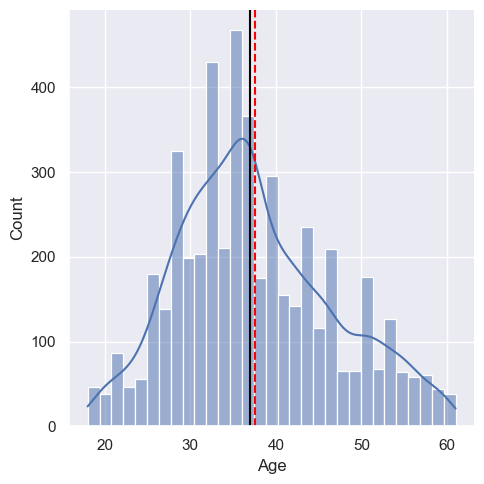

```python
labeldisplot(df, 'Age')
```

We can see our data is close to normal, and wouldn't benefit greatly from log scaling

```python
scaler.fit(df[['Age']])
df[['Age']] = scaler.transform(df[['Age']])
```

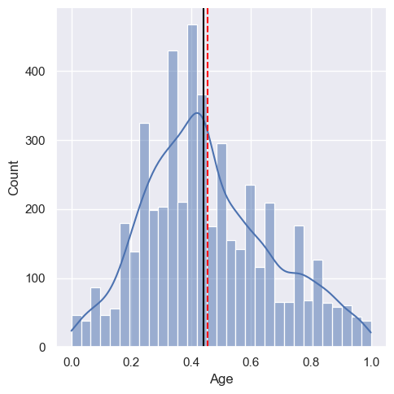

```python
labeldisplot(df, 'Age')
```

We can see the shape of our data remains intact, with its slight right skew but otherwise mostly normal distribution

### Duration of Pitch

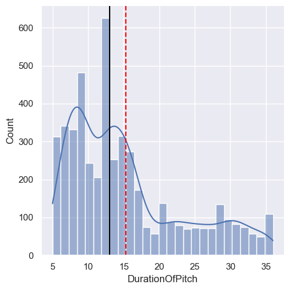

```python
labeldisplot(df, 'DurationOfPitch')
```

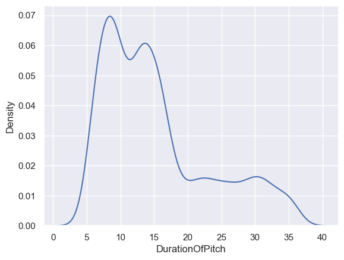

```python
sns.kdeplot(data=df, x="DurationOfPitch", fill=False)
```

```python
df.DurationOfPitch.describe()
```

```
count    4886.000000
mean       15.337700
std         8.003873
min         5.000000
25%         9.000000
50%        13.000000
75%        19.000000
max        36.000000
Name: DurationOfPitch, dtype: float64
```

We don't want the data to stay this way, and a log scale will help us reign in this long right tail, that is all within the whiskers of the data, shifting the center to the right

```python
df['DurationOfPitch'] = np.log(df['DurationOfPitch'])
```

```python
df.DurationOfPitch.describe()
```

```
count    4886.000000
mean        2.603731
std         0.499056
min         1.609438
25%         2.197225
50%         2.564949
75%         2.944439
max         3.583519
Name: DurationOfPitch, dtype: float64
```

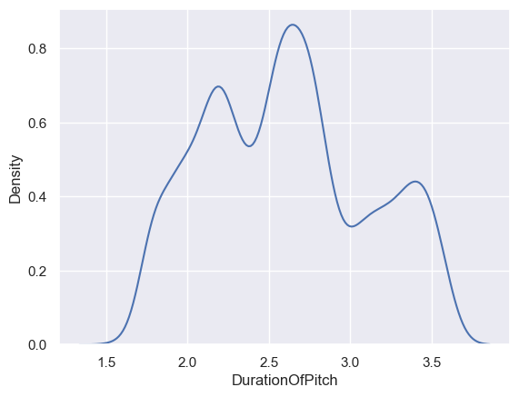

```python
sns.kdeplot(data=df, x="DurationOfPitch", fill=False)
```

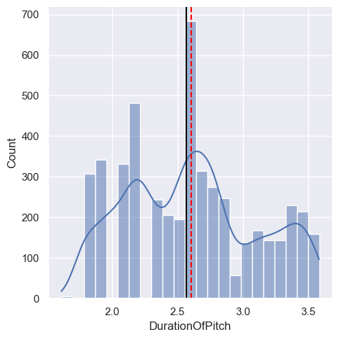

```python
labeldisplot(df, 'DurationOfPitch')
```

This data is still not normal, but it is significantly closer than it would be otherwise, and should help prevent skewing our model, but this requires further testing

### Monthly Income

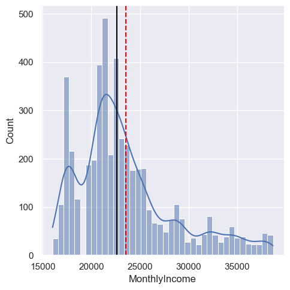

```python
labeldisplot(df, 'MonthlyIncome')
```

This data has the vague structure of a normal distribution, but it has a long right tail that we want to remove and make the dataset as a whole more normal.

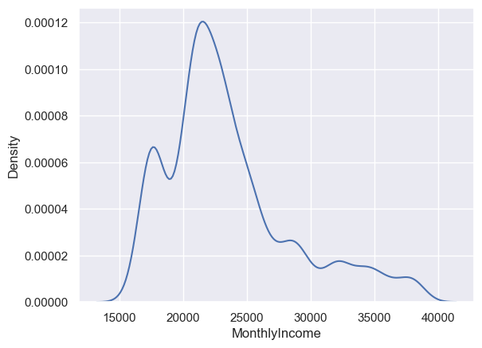

```python
sns.kdeplot(data=df, x="MonthlyIncome", fill=False)
```

```python
df.MonthlyIncome.describe()
```

```
count     4886.000000
mean     23546.899918
std       5026.451397
min      16009.000000
25%      20487.250000
50%      22597.000000
75%      25411.250000
max      38677.000000
Name: MonthlyIncome, dtype: float64
```

```python
df['MonthlyIncome'] = np.log(df['MonthlyIncome'])
```

```python
df.MonthlyIncome.describe()
```

```
count    4886.000000
mean       10.045997
std         0.199718
min         9.680906
25%         9.927558
50%        10.025572
75%        10.142947
max        10.563000
Name: MonthlyIncome, dtype: float64
```

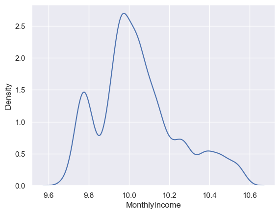

```python
sns.kdeplot(data=df, x="MonthlyIncome", fill=False)
```

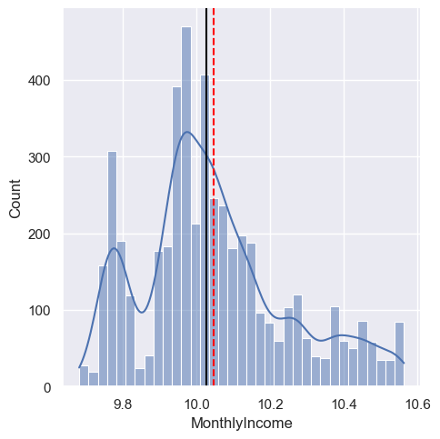

```python
labeldisplot(df, 'MonthlyIncome')
```

This at least shortened the tail, but didn't do an insane amount to normalize the distribution. We will now need to go through and do a min/max encoding due to the numbers being larger than we want, especially in comparison to the rest of the data

```python
scaler.fit(df[['MonthlyIncome']])
df[['MonthlyIncome']] = scaler.transform(df[['MonthlyIncome']])
```

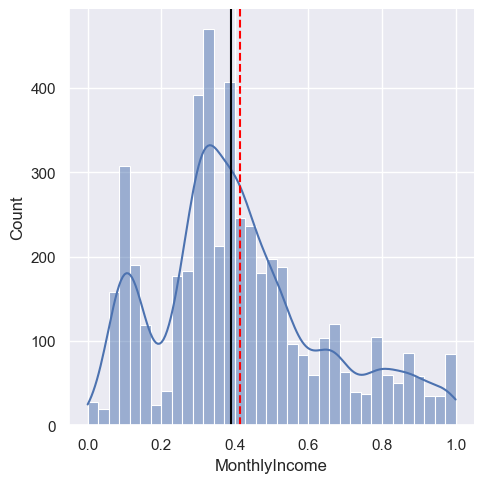

```python
labeldisplot(df, 'MonthlyIncome')
```

We have kept the shape of the data, but left it between 0 and 1.

## Encoding Categorical Values

```python
df.head()
```

|  | ProdTaken | Age | TypeofContact | CityTier | DurationOfPitch | Occupation | Gender | NumberOfFollowups | ProductPitched | PreferredPropertyStar | MaritalStatus | NumberOfTrips | Passport | Designation | MonthlyIncome |
| --- | --- | --- | --- | --- | --- | --- | --- | --- | --- | --- | --- | --- | --- | --- | --- |
| 0 | 1 | 0.534884 | Self Enquiry | 3 | 1.791759 | Salaried | Female | 3.0 | Deluxe | 3.0 | Single | 1-3 | 1 | Management | 0.307267 |
| 1 | 0 | 0.720930 | Company Invited | 1 | 2.639057 | Salaried | Male | 4.0 | Deluxe | 4.0 | Divorced | 1-3 | 0 | Management | 0.259678 |
| 3 | 0 | 0.348837 | Company Invited | 1 | 2.197225 | Salaried | Female | 3.0 | Basic | 3.0 | Divorced | 1-3 | 1 | Executive | 0.127143 |
| 4 | 0 | 0.441860 | Self Enquiry | 1 | 2.079442 | Small Business | Male | 3.0 | Basic | 4.0 | Divorced | 1-3 | 0 | Executive | 0.161988 |
| 5 | 0 | 0.325581 | Company Invited | 1 | 2.079442 | Salaried | Male | 3.0 | Basic | 3.0 | Single | 1-3 | 0 | Executive | 0.137164 |

Type of Contact, Occupation, gender, ProductPitched, Marital Status, Number of Trips, and Designation are all non-numeric and will need to be encoded using either onehot or label encoding. Given that we already have a large number of columns, we will be utilizing Lable Encoding for these values.

### Type of Contact

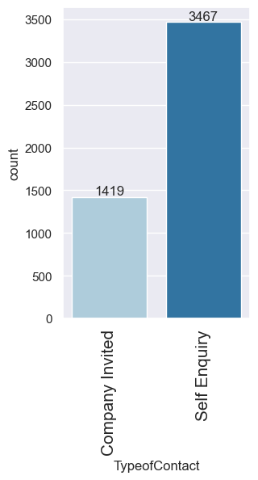

```python
labeledbarplot(df, 'TypeofContact')
```

```python
df.head(5)
```

|  | ProdTaken | Age | TypeofContact | CityTier | DurationOfPitch | Occupation | Gender | NumberOfFollowups | ProductPitched | PreferredPropertyStar | MaritalStatus | NumberOfTrips | Passport | Designation | MonthlyIncome |
| --- | --- | --- | --- | --- | --- | --- | --- | --- | --- | --- | --- | --- | --- | --- | --- |
| 0 | 1 | 0.534884 | Self Enquiry | 3 | 1.791759 | Salaried | Female | 3.0 | Deluxe | 3.0 | Single | 1-3 | 1 | Management | 0.307267 |
| 1 | 0 | 0.720930 | Company Invited | 1 | 2.639057 | Salaried | Male | 4.0 | Deluxe | 4.0 | Divorced | 1-3 | 0 | Management | 0.259678 |
| 3 | 0 | 0.348837 | Company Invited | 1 | 2.197225 | Salaried | Female | 3.0 | Basic | 3.0 | Divorced | 1-3 | 1 | Executive | 0.127143 |
| 4 | 0 | 0.441860 | Self Enquiry | 1 | 2.079442 | Small Business | Male | 3.0 | Basic | 4.0 | Divorced | 1-3 | 0 | Executive | 0.161988 |
| 5 | 0 | 0.325581 | Company Invited | 1 | 2.079442 | Salaried | Male | 3.0 | Basic | 3.0 | Single | 1-3 | 0 | Executive | 0.137164 |

#### Transforming the Data with Label Encoder

```python
df['TypeofContact'] = labelEncoder.fit_transform(df['TypeofContact'])
```

```python
df.head(5)
```

|  | ProdTaken | Age | TypeofContact | CityTier | DurationOfPitch | Occupation | Gender | NumberOfFollowups | ProductPitched | PreferredPropertyStar | MaritalStatus | NumberOfTrips | Passport | Designation | MonthlyIncome |
| --- | --- | --- | --- | --- | --- | --- | --- | --- | --- | --- | --- | --- | --- | --- | --- |
| 0 | 1 | 0.534884 | 1 | 3 | 1.791759 | Salaried | Female | 3.0 | Deluxe | 3.0 | Single | 1-3 | 1 | Management | 0.307267 |
| 1 | 0 | 0.720930 | 0 | 1 | 2.639057 | Salaried | Male | 4.0 | Deluxe | 4.0 | Divorced | 1-3 | 0 | Management | 0.259678 |
| 3 | 0 | 0.348837 | 0 | 1 | 2.197225 | Salaried | Female | 3.0 | Basic | 3.0 | Divorced | 1-3 | 1 | Executive | 0.127143 |
| 4 | 0 | 0.441860 | 1 | 1 | 2.079442 | Small Business | Male | 3.0 | Basic | 4.0 | Divorced | 1-3 | 0 | Executive | 0.161988 |
| 5 | 0 | 0.325581 | 0 | 1 | 2.079442 | Salaried | Male | 3.0 | Basic | 3.0 | Single | 1-3 | 0 | Executive | 0.137164 |

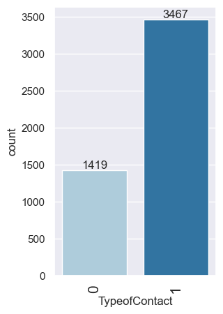

```python
labeledbarplot(df, 'TypeofContact')
```

### Occupation

```python
df.head(5)
```

|  | ProdTaken | Age | TypeofContact | CityTier | DurationOfPitch | Occupation | Gender | NumberOfFollowups | ProductPitched | PreferredPropertyStar | MaritalStatus | NumberOfTrips | Passport | Designation | MonthlyIncome |
| --- | --- | --- | --- | --- | --- | --- | --- | --- | --- | --- | --- | --- | --- | --- | --- |
| 0 | 1 | 0.534884 | 1 | 3 | 1.791759 | Salaried | Female | 3.0 | Deluxe | 3.0 | Single | 1-3 | 1 | Management | 0.307267 |
| 1 | 0 | 0.720930 | 0 | 1 | 2.639057 | Salaried | Male | 4.0 | Deluxe | 4.0 | Divorced | 1-3 | 0 | Management | 0.259678 |
| 3 | 0 | 0.348837 | 0 | 1 | 2.197225 | Salaried | Female | 3.0 | Basic | 3.0 | Divorced | 1-3 | 1 | Executive | 0.127143 |
| 4 | 0 | 0.441860 | 1 | 1 | 2.079442 | Small Business | Male | 3.0 | Basic | 4.0 | Divorced | 1-3 | 0 | Executive | 0.161988 |
| 5 | 0 | 0.325581 | 0 | 1 | 2.079442 | Salaried | Male | 3.0 | Basic | 3.0 | Single | 1-3 | 0 | Executive | 0.137164 |

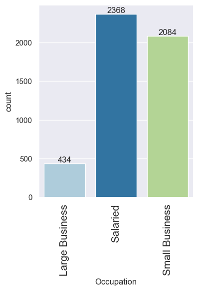

```python
labeledbarplot(df, 'Occupation')
```

#### Transforming the Data with Label Encoder

```python
df['Occupation'] = labelEncoder.fit_transform(df['Occupation'])
```

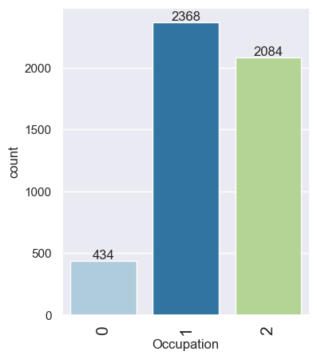

```python
labeledbarplot(df, 'Occupation')
```

```python
df.head(5)
```

|  | ProdTaken | Age | TypeofContact | CityTier | DurationOfPitch | Occupation | Gender | NumberOfFollowups | ProductPitched | PreferredPropertyStar | MaritalStatus | NumberOfTrips | Passport | Designation | MonthlyIncome |
| --- | --- | --- | --- | --- | --- | --- | --- | --- | --- | --- | --- | --- | --- | --- | --- |
| 0 | 1 | 0.534884 | 1 | 3 | 1.791759 | 1 | Female | 3.0 | Deluxe | 3.0 | Single | 1-3 | 1 | Management | 0.307267 |
| 1 | 0 | 0.720930 | 0 | 1 | 2.639057 | 1 | Male | 4.0 | Deluxe | 4.0 | Divorced | 1-3 | 0 | Management | 0.259678 |
| 3 | 0 | 0.348837 | 0 | 1 | 2.197225 | 1 | Female | 3.0 | Basic | 3.0 | Divorced | 1-3 | 1 | Executive | 0.127143 |
| 4 | 0 | 0.441860 | 1 | 1 | 2.079442 | 2 | Male | 3.0 | Basic | 4.0 | Divorced | 1-3 | 0 | Executive | 0.161988 |
| 5 | 0 | 0.325581 | 0 | 1 | 2.079442 | 1 | Male | 3.0 | Basic | 3.0 | Single | 1-3 | 0 | Executive | 0.137164 |

### Gender

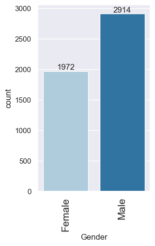

```python
labeledbarplot(df, 'Gender')
```

```python
df.head(5)
```

|  | ProdTaken | Age | TypeofContact | CityTier | DurationOfPitch | Occupation | Gender | NumberOfFollowups | ProductPitched | PreferredPropertyStar | MaritalStatus | NumberOfTrips | Passport | Designation | MonthlyIncome |
| --- | --- | --- | --- | --- | --- | --- | --- | --- | --- | --- | --- | --- | --- | --- | --- |
| 0 | 1 | 0.534884 | 1 | 3 | 1.791759 | 1 | Female | 3.0 | Deluxe | 3.0 | Single | 1-3 | 1 | Management | 0.307267 |
| 1 | 0 | 0.720930 | 0 | 1 | 2.639057 | 1 | Male | 4.0 | Deluxe | 4.0 | Divorced | 1-3 | 0 | Management | 0.259678 |
| 3 | 0 | 0.348837 | 0 | 1 | 2.197225 | 1 | Female | 3.0 | Basic | 3.0 | Divorced | 1-3 | 1 | Executive | 0.127143 |
| 4 | 0 | 0.441860 | 1 | 1 | 2.079442 | 2 | Male | 3.0 | Basic | 4.0 | Divorced | 1-3 | 0 | Executive | 0.161988 |
| 5 | 0 | 0.325581 | 0 | 1 | 2.079442 | 1 | Male | 3.0 | Basic | 3.0 | Single | 1-3 | 0 | Executive | 0.137164 |

#### Transforming the Data with Label Encoder

```python
df['Gender'] = labelEncoder.fit_transform(df['Gender'])
```

```python
df.head(5)
```

|  | ProdTaken | Age | TypeofContact | CityTier | DurationOfPitch | Occupation | Gender | NumberOfFollowups | ProductPitched | PreferredPropertyStar | MaritalStatus | NumberOfTrips | Passport | Designation | MonthlyIncome |
| --- | --- | --- | --- | --- | --- | --- | --- | --- | --- | --- | --- | --- | --- | --- | --- |
| 0 | 1 | 0.534884 | 1 | 3 | 1.791759 | 1 | 0 | 3.0 | Deluxe | 3.0 | Single | 1-3 | 1 | Management | 0.307267 |
| 1 | 0 | 0.720930 | 0 | 1 | 2.639057 | 1 | 1 | 4.0 | Deluxe | 4.0 | Divorced | 1-3 | 0 | Management | 0.259678 |
| 3 | 0 | 0.348837 | 0 | 1 | 2.197225 | 1 | 0 | 3.0 | Basic | 3.0 | Divorced | 1-3 | 1 | Executive | 0.127143 |
| 4 | 0 | 0.441860 | 1 | 1 | 2.079442 | 2 | 1 | 3.0 | Basic | 4.0 | Divorced | 1-3 | 0 | Executive | 0.161988 |
| 5 | 0 | 0.325581 | 0 | 1 | 2.079442 | 1 | 1 | 3.0 | Basic | 3.0 | Single | 1-3 | 0 | Executive | 0.137164 |

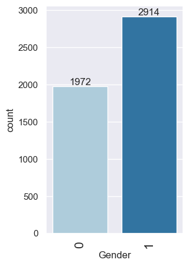

```python
labeledbarplot(df, 'Gender')
```

### Product Pitched

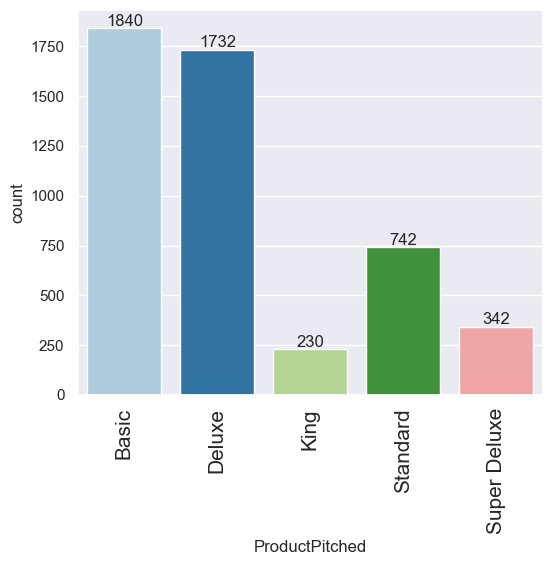

```python
labeledbarplot(df, 'ProductPitched')
```

```python
df.head(5)
```

|  | ProdTaken | Age | TypeofContact | CityTier | DurationOfPitch | Occupation | Gender | NumberOfFollowups | ProductPitched | PreferredPropertyStar | MaritalStatus | NumberOfTrips | Passport | Designation | MonthlyIncome |
| --- | --- | --- | --- | --- | --- | --- | --- | --- | --- | --- | --- | --- | --- | --- | --- |
| 0 | 1 | 0.534884 | 1 | 3 | 1.791759 | 1 | 0 | 3.0 | Deluxe | 3.0 | Single | 1-3 | 1 | Management | 0.307267 |
| 1 | 0 | 0.720930 | 0 | 1 | 2.639057 | 1 | 1 | 4.0 | Deluxe | 4.0 | Divorced | 1-3 | 0 | Management | 0.259678 |
| 3 | 0 | 0.348837 | 0 | 1 | 2.197225 | 1 | 0 | 3.0 | Basic | 3.0 | Divorced | 1-3 | 1 | Executive | 0.127143 |
| 4 | 0 | 0.441860 | 1 | 1 | 2.079442 | 2 | 1 | 3.0 | Basic | 4.0 | Divorced | 1-3 | 0 | Executive | 0.161988 |
| 5 | 0 | 0.325581 | 0 | 1 | 2.079442 | 1 | 1 | 3.0 | Basic | 3.0 | Single | 1-3 | 0 | Executive | 0.137164 |

#### Transforming the Data with Label Encoder

```python
df['ProductPitched'] = labelEncoder.fit_transform(df['ProductPitched'])
```

```python
df.head(5)
```

|  | ProdTaken | Age | TypeofContact | CityTier | DurationOfPitch | Occupation | Gender | NumberOfFollowups | ProductPitched | PreferredPropertyStar | MaritalStatus | NumberOfTrips | Passport | Designation | MonthlyIncome |
| --- | --- | --- | --- | --- | --- | --- | --- | --- | --- | --- | --- | --- | --- | --- | --- |
| 0 | 1 | 0.534884 | 1 | 3 | 1.791759 | 1 | 0 | 3.0 | 1 | 3.0 | Single | 1-3 | 1 | Management | 0.307267 |
| 1 | 0 | 0.720930 | 0 | 1 | 2.639057 | 1 | 1 | 4.0 | 1 | 4.0 | Divorced | 1-3 | 0 | Management | 0.259678 |
| 3 | 0 | 0.348837 | 0 | 1 | 2.197225 | 1 | 0 | 3.0 | 0 | 3.0 | Divorced | 1-3 | 1 | Executive | 0.127143 |
| 4 | 0 | 0.441860 | 1 | 1 | 2.079442 | 2 | 1 | 3.0 | 0 | 4.0 | Divorced | 1-3 | 0 | Executive | 0.161988 |
| 5 | 0 | 0.325581 | 0 | 1 | 2.079442 | 1 | 1 | 3.0 | 0 | 3.0 | Single | 1-3 | 0 | Executive | 0.137164 |

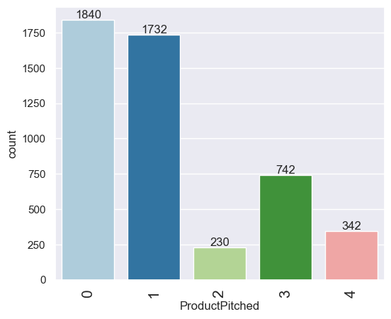

```python
labeledbarplot(df, 'ProductPitched')
```

### Marital Status

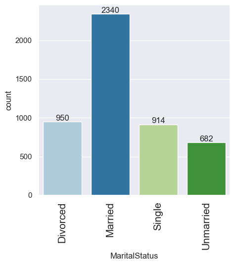

```python
labeledbarplot(df, 'MaritalStatus')
```

```python
df.head(5)
```

|  | ProdTaken | Age | TypeofContact | CityTier | DurationOfPitch | Occupation | Gender | NumberOfFollowups | ProductPitched | PreferredPropertyStar | MaritalStatus | NumberOfTrips | Passport | Designation | MonthlyIncome |
| --- | --- | --- | --- | --- | --- | --- | --- | --- | --- | --- | --- | --- | --- | --- | --- |
| 0 | 1 | 0.534884 | 1 | 3 | 1.791759 | 1 | 0 | 3.0 | 1 | 3.0 | Single | 1-3 | 1 | Management | 0.307267 |
| 1 | 0 | 0.720930 | 0 | 1 | 2.639057 | 1 | 1 | 4.0 | 1 | 4.0 | Divorced | 1-3 | 0 | Management | 0.259678 |
| 3 | 0 | 0.348837 | 0 | 1 | 2.197225 | 1 | 0 | 3.0 | 0 | 3.0 | Divorced | 1-3 | 1 | Executive | 0.127143 |
| 4 | 0 | 0.441860 | 1 | 1 | 2.079442 | 2 | 1 | 3.0 | 0 | 4.0 | Divorced | 1-3 | 0 | Executive | 0.161988 |
| 5 | 0 | 0.325581 | 0 | 1 | 2.079442 | 1 | 1 | 3.0 | 0 | 3.0 | Single | 1-3 | 0 | Executive | 0.137164 |

#### Transforming the Data with Label Encoder

```python
df['MaritalStatus'] = labelEncoder.fit_transform(df['MaritalStatus'])
```

```python
df.head(5)
```

|  | ProdTaken | Age | TypeofContact | CityTier | DurationOfPitch | Occupation | Gender | NumberOfFollowups | ProductPitched | PreferredPropertyStar | MaritalStatus | NumberOfTrips | Passport | Designation | MonthlyIncome |
| --- | --- | --- | --- | --- | --- | --- | --- | --- | --- | --- | --- | --- | --- | --- | --- |
| 0 | 1 | 0.534884 | 1 | 3 | 1.791759 | 1 | 0 | 3.0 | 1 | 3.0 | 2 | 1-3 | 1 | Management | 0.307267 |
| 1 | 0 | 0.720930 | 0 | 1 | 2.639057 | 1 | 1 | 4.0 | 1 | 4.0 | 0 | 1-3 | 0 | Management | 0.259678 |
| 3 | 0 | 0.348837 | 0 | 1 | 2.197225 | 1 | 0 | 3.0 | 0 | 3.0 | 0 | 1-3 | 1 | Executive | 0.127143 |
| 4 | 0 | 0.441860 | 1 | 1 | 2.079442 | 2 | 1 | 3.0 | 0 | 4.0 | 0 | 1-3 | 0 | Executive | 0.161988 |
| 5 | 0 | 0.325581 | 0 | 1 | 2.079442 | 1 | 1 | 3.0 | 0 | 3.0 | 2 | 1-3 | 0 | Executive | 0.137164 |

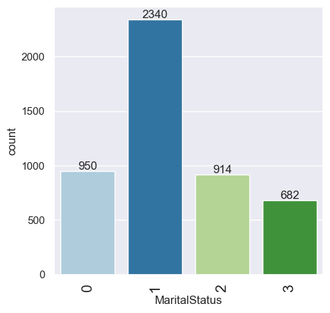

```python
labeledbarplot(df, 'MaritalStatus')
```

### Number of Trips

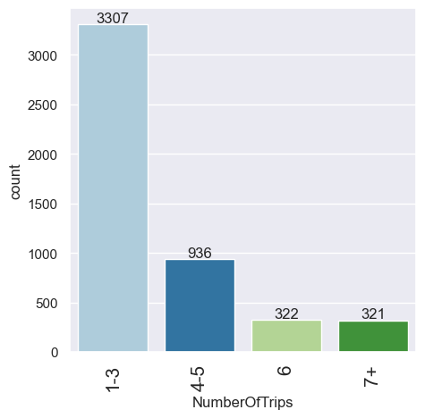

```python
labeledbarplot(df, 'NumberOfTrips')
```

```python
df.head(10)
```

|  | ProdTaken | Age | TypeofContact | CityTier | DurationOfPitch | Occupation | Gender | NumberOfFollowups | ProductPitched | PreferredPropertyStar | MaritalStatus | NumberOfTrips | Passport | Designation | MonthlyIncome |
| --- | --- | --- | --- | --- | --- | --- | --- | --- | --- | --- | --- | --- | --- | --- | --- |
| 0 | 1 | 0.534884 | 1 | 3 | 1.791759 | 1 | 0 | 3.0 | 1 | 3.0 | 2 | 1-3 | 1 | Management | 0.307267 |
| 1 | 0 | 0.720930 | 0 | 1 | 2.639057 | 1 | 1 | 4.0 | 1 | 4.0 | 0 | 1-3 | 0 | Management | 0.259678 |
| 3 | 0 | 0.348837 | 0 | 1 | 2.197225 | 1 | 0 | 3.0 | 0 | 3.0 | 0 | 1-3 | 1 | Executive | 0.127143 |
| 4 | 0 | 0.441860 | 1 | 1 | 2.079442 | 2 | 1 | 3.0 | 0 | 4.0 | 0 | 1-3 | 0 | Executive | 0.161988 |
| 5 | 0 | 0.325581 | 0 | 1 | 2.079442 | 1 | 1 | 3.0 | 0 | 3.0 | 2 | 1-3 | 0 | Executive | 0.137164 |
| 6 | 0 | 0.953488 | 1 | 1 | 2.197225 | 2 | 0 | 2.0 | 0 | 5.0 | 0 | 4-5 | 1 | Executive | 0.111912 |
| 7 | 0 | 0.279070 | 1 | 1 | 3.401197 | 1 | 1 | 3.0 | 0 | 3.0 | 1 | 1-3 | 0 | Executive | 0.113387 |
| 8 | 0 | 0.465116 | 0 | 1 | 3.367296 | 1 | 1 | 4.0 | 3 | 3.0 | 3 | 1-3 | 0 | Management | 0.483602 |
| 9 | 0 | 0.418605 | 1 | 1 | 3.496508 | 2 | 1 | 3.0 | 1 | 3.0 | 0 | 7+ | 0 | Management | 0.265688 |
| 10 | 0 | 0.395349 | 1 | 1 | 3.091042 | 2 | 1 | 2.0 | 0 | 4.0 | 0 | 1-3 | 0 | Executive | 0.096149 |

#### Transforming the Data with Label Encoder

```python
df['NumberOfTrips'] = labelEncoder.fit_transform(df['NumberOfTrips'])
```

```python
df.head(10)
```

|  | ProdTaken | Age | TypeofContact | CityTier | DurationOfPitch | Occupation | Gender | NumberOfFollowups | ProductPitched | PreferredPropertyStar | MaritalStatus | NumberOfTrips | Passport | Designation | MonthlyIncome |
| --- | --- | --- | --- | --- | --- | --- | --- | --- | --- | --- | --- | --- | --- | --- | --- |
| 0 | 1 | 0.534884 | 1 | 3 | 1.791759 | 1 | 0 | 3.0 | 1 | 3.0 | 2 | 0 | 1 | Management | 0.307267 |
| 1 | 0 | 0.720930 | 0 | 1 | 2.639057 | 1 | 1 | 4.0 | 1 | 4.0 | 0 | 0 | 0 | Management | 0.259678 |
| 3 | 0 | 0.348837 | 0 | 1 | 2.197225 | 1 | 0 | 3.0 | 0 | 3.0 | 0 | 0 | 1 | Executive | 0.127143 |
| 4 | 0 | 0.441860 | 1 | 1 | 2.079442 | 2 | 1 | 3.0 | 0 | 4.0 | 0 | 0 | 0 | Executive | 0.161988 |
| 5 | 0 | 0.325581 | 0 | 1 | 2.079442 | 1 | 1 | 3.0 | 0 | 3.0 | 2 | 0 | 0 | Executive | 0.137164 |
| 6 | 0 | 0.953488 | 1 | 1 | 2.197225 | 2 | 0 | 2.0 | 0 | 5.0 | 0 | 1 | 1 | Executive | 0.111912 |
| 7 | 0 | 0.279070 | 1 | 1 | 3.401197 | 1 | 1 | 3.0 | 0 | 3.0 | 1 | 0 | 0 | Executive | 0.113387 |
| 8 | 0 | 0.465116 | 0 | 1 | 3.367296 | 1 | 1 | 4.0 | 3 | 3.0 | 3 | 0 | 0 | Management | 0.483602 |
| 9 | 0 | 0.418605 | 1 | 1 | 3.496508 | 2 | 1 | 3.0 | 1 | 3.0 | 0 | 3 | 0 | Management | 0.265688 |
| 10 | 0 | 0.395349 | 1 | 1 | 3.091042 | 2 | 1 | 2.0 | 0 | 4.0 | 0 | 0 | 0 | Executive | 0.096149 |

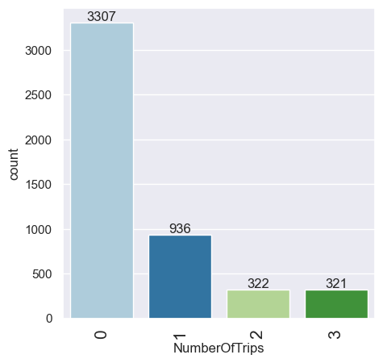

```python
labeledbarplot(df, 'NumberOfTrips')
```